# Kmeans

# Use and Applications

Kmeans (MacQueen, 1967) is a a process for partitioning an N-dimensional population into k sets on the basis of a sample. The most relevant application is **clustering** or similarity grouping. In this case the objective is not to find some unique, definitive grouping, but rather to simply aid the investigator in obtaining qualitative and quantitative understanding of large amounts of N-dimensional data by providing him with reasonably good similarity groups. The method should be used in close interaction with theory and intuition. Other applications include: classification, approximating a general distribution, scrambled dimension test for independence among several variables, distance-based classification trees, lossy image compression.

# Theory

```r
require(readr)
require(dplyr)
require(tidyr)
require(stringr)
require(ggplot2)
```

# Examples with R

I use the famous **iris** dataset to demonstrate the basic usage of **kmeans** function in **stat** package. From an exploratory bivariate graphical analysis it seems that petal length and width discriminate well between species as it can be seen from the scatter plot below.

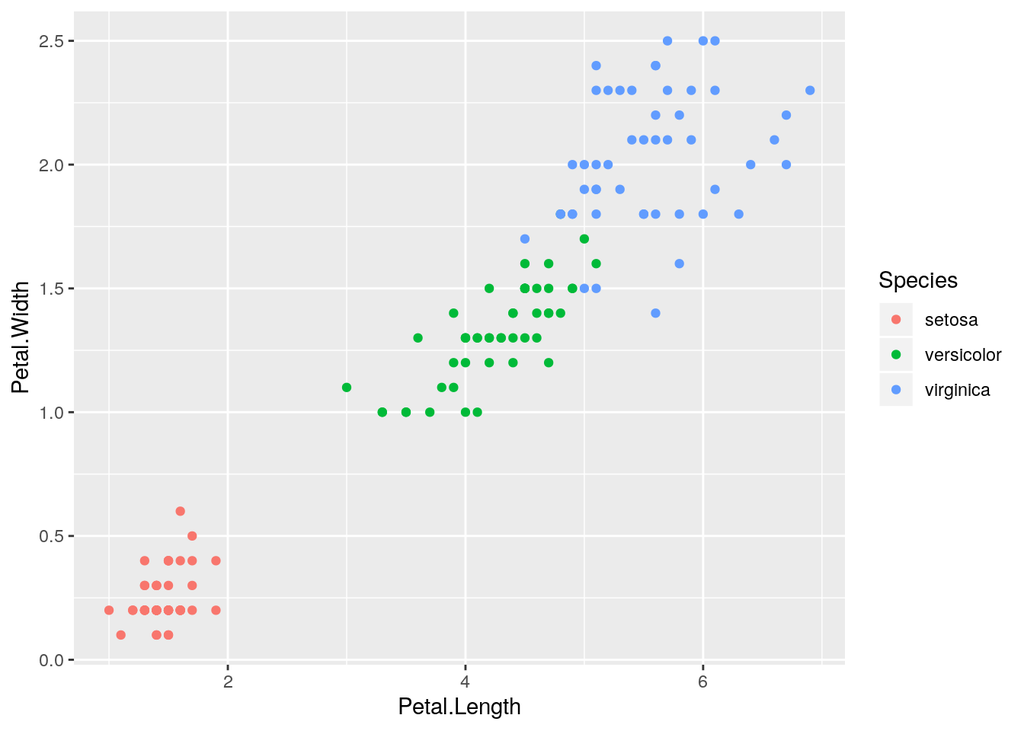

```r
df <- iris

ggplot(df, aes(Petal.Length, Petal.Width, col = Species)) +
  geom_point()
```

Fitting a kmeans model setting k = 3 (using the prior information about species) produces 3 clusters very similar to the actual species.

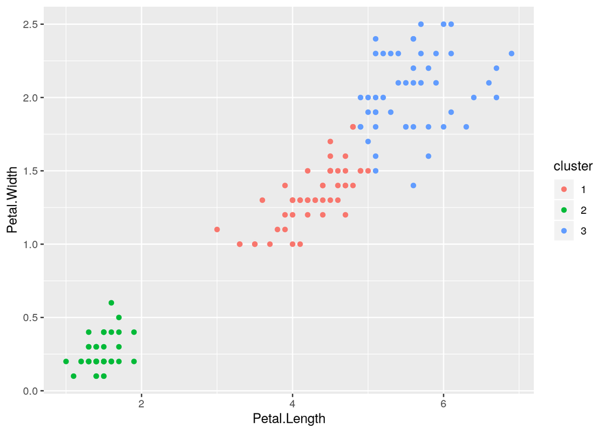

```r
df <- df %>% select(Petal.Length, Petal.Width)

# fitting kmeans
fm <- kmeans(df, centers = 3)

# bind cluster association
df <- df %>% bind_cols(tibble(cluster = as.character(fm$cluster)))

ggplot(df, aes(Petal.Length, Petal.Width, col = cluster)) +
  geom_point()
```

```r
data <- './italy_risk.csv'
data <- read_delim(data, delim = ',')
data_sel <- data %>% select(DZCOM, IVSM, VECCH, IDR_AREAP3, PAI_AREAP3_P4, SUP) %>%
  mutate(IDR_AREAP3 = as.numeric(str_replace(IDR_AREAP3, ',', '\\.'))/SUP,
         PAI_AREAP3_P4 = as.numeric(str_replace(PAI_AREAP3_P4, ',', '\\.'))/SUP)

ggplot(data_sel, aes(PAI_AREAP3_P4, IDR_AREAP3)) +
  geom_point()
```

[output not shown]

## Image compression

Original picture

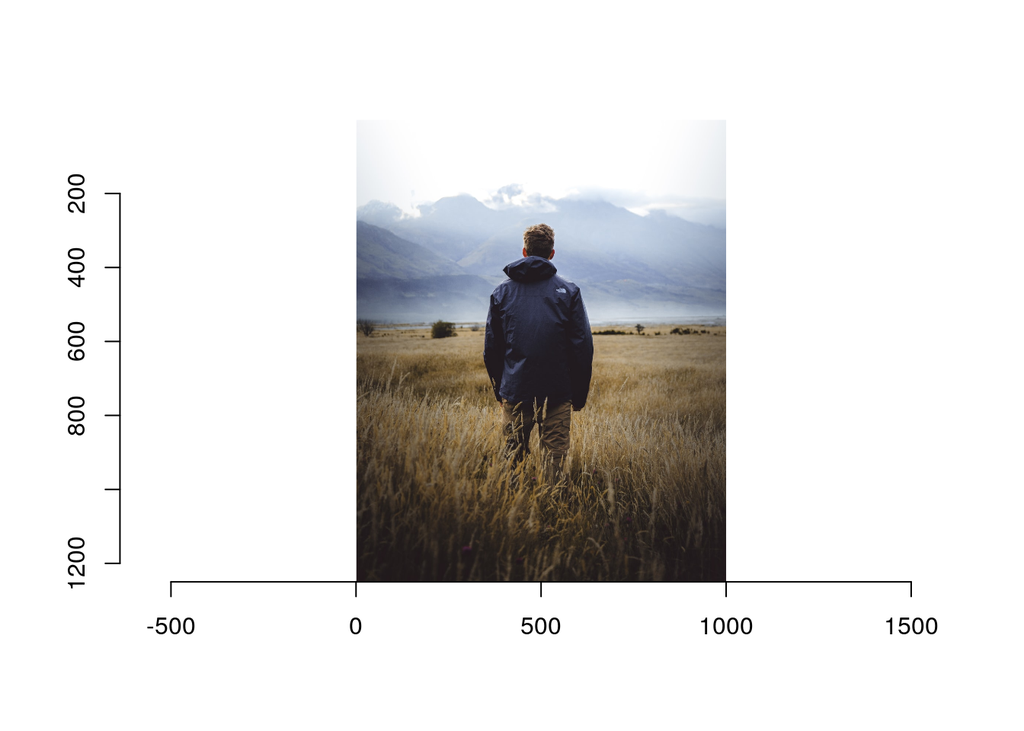

```r
require(imager)

# Load pic
img <- load.image("./photo-1503023345310-bd7c1de61c7d.jpeg")
dim_img <- dim(img)

plot(img)
```

Compressed picture with 10 colors

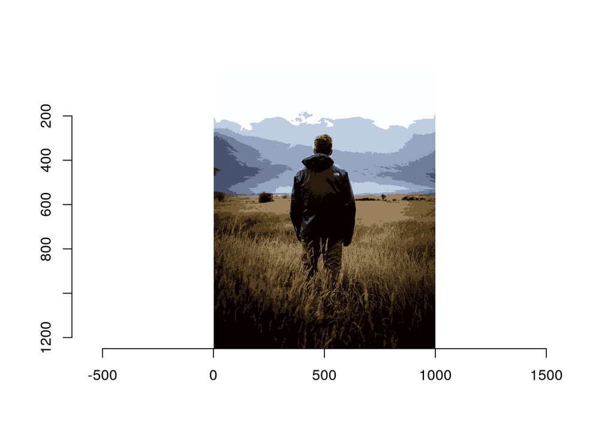

```r
# Make dataframe
df_img <- as.data.frame(img)

df_img <- df_img %>%
  spread(cc, value)

df_coord <- df_img %>% select(x, y)
df <- df_img %>% select(`1`, `2`, `3`)

# perfom K-means
k <- 10
max_iter <- 100
fm <- kmeans(df, centers = k, iter.max = max_iter, nstart = 1)

df <- df %>% bind_cols(tibble(cluster = as.character(fm$cluster)))

df_kmeans <- as.data.frame(fm$centers) %>%
  bind_cols(tibble(cluster = as.character(seq_len(nrow(fm$centers)))))

df <- df %>%
  select(cluster) %>%
  inner_join(df_kmeans, by = 'cluster') %>%
  select(-cluster)

df <- df_coord %>% bind_cols(df)

df <- df %>%
  gather('cc', 'value', -x, -y)

df <- df %>%
  arrange(cc, y, x) %>%
  select(x, y, cc, value) %>%
  mutate(cc = as.numeric(cc))

img <- as.cimg(df, dims = dim_img)

# Plot
plot(img)
```

Compressed picture with 3 colors

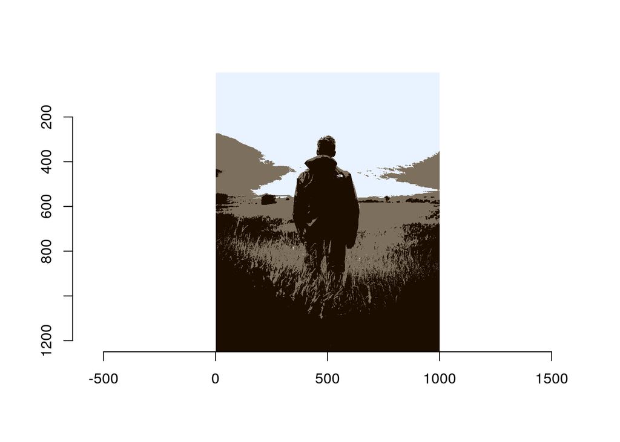